# Taller 04

Oscar Joseph Rodriguez

31/8/2021

# Procesamiento de datos con R

descargar los datos de los archivos:

- Soil_Data.csv
- Weather_Data.csv
- Dataset_Maize_Cordoba_Data_cleanning.csv

Tambien descargar el libro:

- Codebook_Dataset_Maize_Cordoba_Data_cleaning.xlsx

además, se deberá utilizar los paquetes:

- dplyr
- tidyr

el codigo debe ser escrito en Rmarkdown.

```r
library(dplyr)
library(tidyr)
```

```r
Soil_data <- read.csv("Datos/Soil_Data.csv", stringsAsFactors = T)
Weather_data <- read.csv("Datos/Weather_Data.csv" , stringsAsFactors = T)
Manage_data <- read.csv("Datos/Dataset_Maize_Cordoba_Data_cleaning.csv" ,
                        stringsAsFactors = T)
```

## 1.Leyendo y unificando datos

Se uniran las bases de datos Soil_data, Weather_data y Manage_data en una nueva tabla Total_data, utilizando como base los datos de manejo

```r
Total_data <- Manage_data %>% full_join(Soil_data, by="ID")
Total_data <- Total_data %>% full_join(Weather_data, by = "ID")
```

### Seleccionar datos válidos

Se quitaran los datos que tienen el valor NA, utilizando la seleccion de **complete.cases**

```r
Total_data <- Total_data[complete.cases(Total_data),]
```

Se removieron los datos a datos completos, para poder hacer un analisis completo y teniendo en consideracion que en los resumenes de datos habia pocos datos *NA*, pero estaban en ubicaciones diferentes

## 2.Ejecutando la limpieza de datos

Se colocaran las fechas en el formato adecuado, utilizando la funcion **as.Date**

```r
 Total_data <- Total_data %>% mutate(Planting_Date=as.Date(Planting_Date,"%m/%d/%Y"),
                                    Harvest_Date=as.Date(Harvest_Date,"%m/%d/%Y"))
```

```r
Total_data <- Total_data %>% mutate(Longitud_ciclo= as.numeric(Harvest_Date-Planting_Date))
```

Se convertiran las variables de texto a mayusculas con la funcion **toupper**

```r
Total_data <- Total_data %>% mutate(Sowing_Method = toupper(Sowing_Method),
                                    Cultivar = toupper(Cultivar),
                                    Former_Crop = toupper(Former_Crop),
                                    Departemento = toupper(Departemento),
                                    Harvest_Method = toupper(Harvest_Method),
                                    Cultivar_Type = toupper(Cultivar_Type),
                                    Soil_Texture = toupper(Soil_Texture))
```

Se corregiran los valores de **Yield** debido a la diferencia al momento de registrar

```r
library(stringr)
Total_data <- Total_data %>% mutate(Yield=str_replace(Total_data$Yield, "," , "."))
```

Se corregira el valor de **Yield** a numerico

```r
Total_data <- Total_data %>% mutate(Yield = as.numeric(Yield, type="double"))
```

Se corrigieron los valores de *“,”* por *“.”* utilizando la funcion *str_replace* del paquete *stringr*, luego se cambiaron los datos de caracter a numerico

## 3.Detectando y procesando valores atipicos

Generar un boxplot para el rendimiento, densidad planta y longitud de ciclo

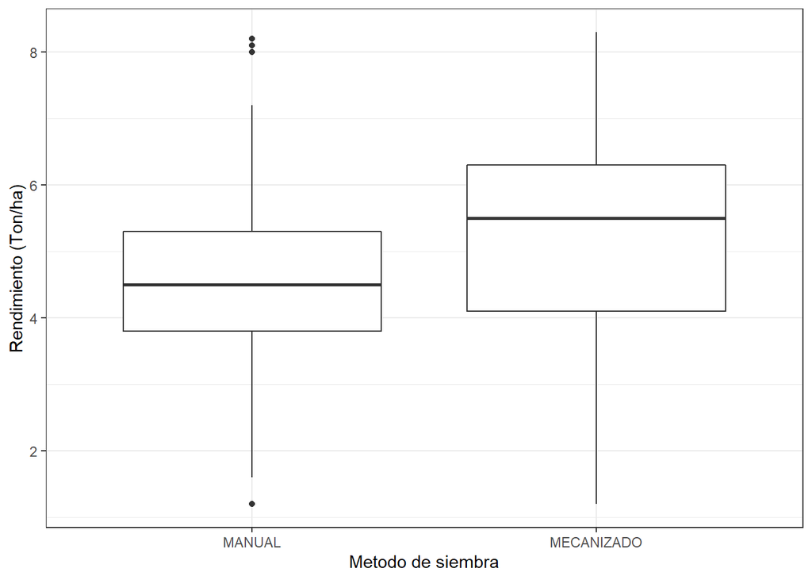

```r
library(ggplot2)
ggplot(Total_data,aes(x=Sowing_Method, y=Yield))+geom_boxplot()+
  xlab("Metodo de siembra")+
  ylab("Rendimiento (Ton/ha)")+
  theme_bw()
```

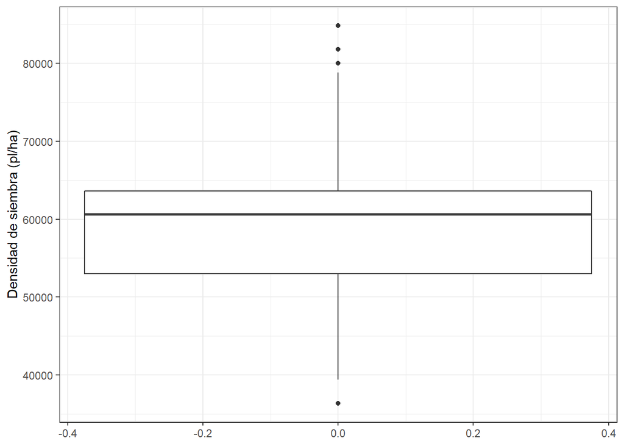

```r
ggplot(Total_data,aes(y=Sowing_Seeds_Number))+geom_boxplot()+
  ylab("Densidad de siembra (pl/ha)")+
  theme_bw()
```

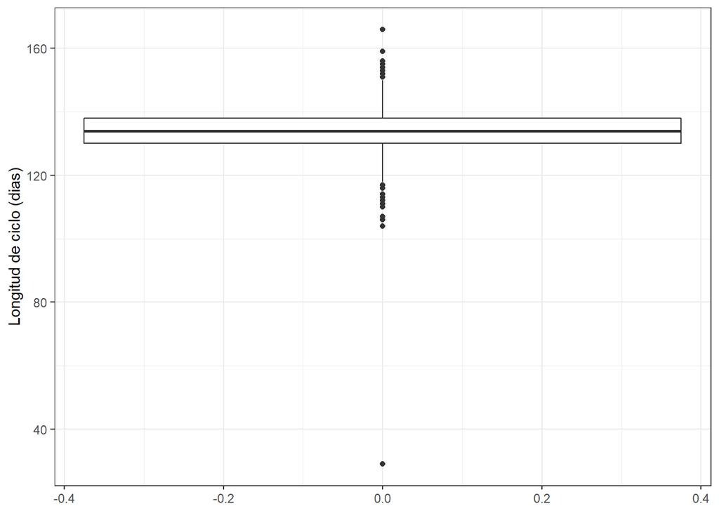

```r
ggplot(Total_data,aes(y=Longitud_ciclo))+geom_boxplot()+
  ylab("Longitud de ciclo (dias)")+
  theme_bw()
```

Identificar y reemplazar por NA, solamente los valores extremadamente atipicos

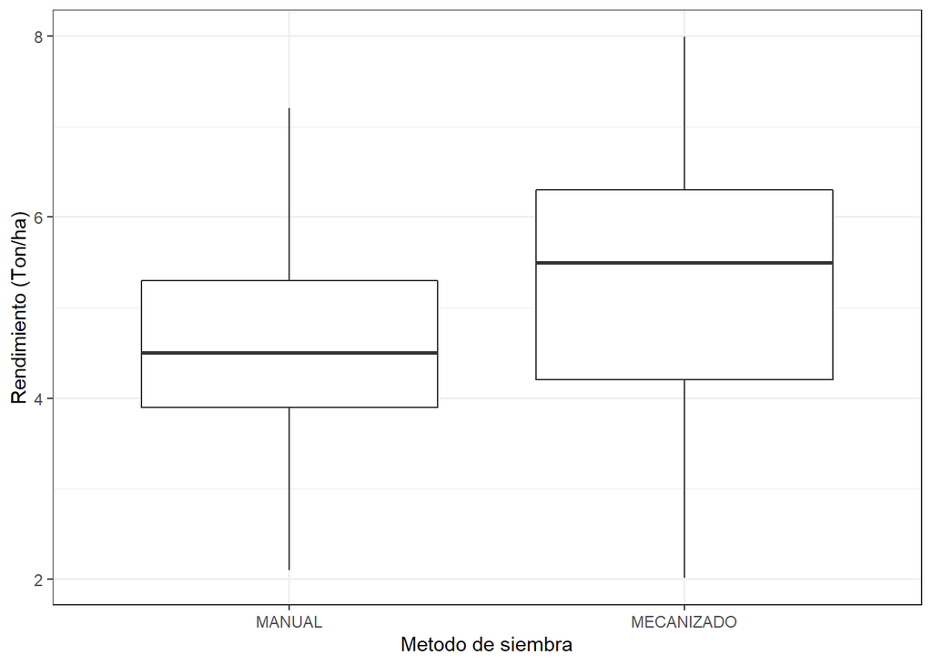

```r
Total_data <- Total_data %>% filter(Yield<8) %>%
  filter(Yield >2)

ggplot(Total_data,aes(x=Sowing_Method, y=Yield))+geom_boxplot()+
  xlab("Metodo de siembra")+
  ylab("Rendimiento (Ton/ha)")+
  theme_bw()
```

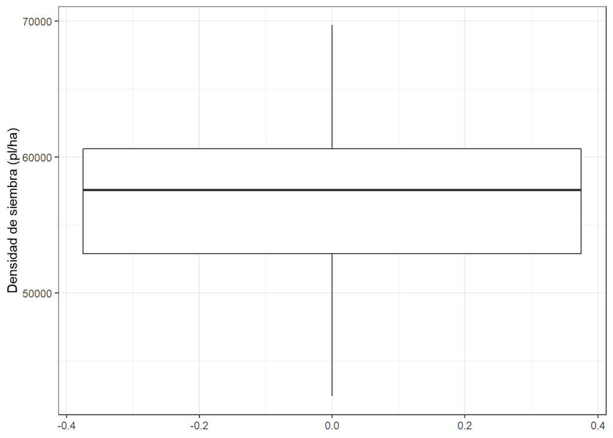

```r
Total_data <- Total_data %>% filter(Sowing_Seeds_Number < 70000) %>%
  filter(Sowing_Seeds_Number >42000)

ggplot(Total_data,aes(y=Sowing_Seeds_Number))+geom_boxplot()+
  ylab("Densidad de siembra (pl/ha)")+
  theme_bw()
```

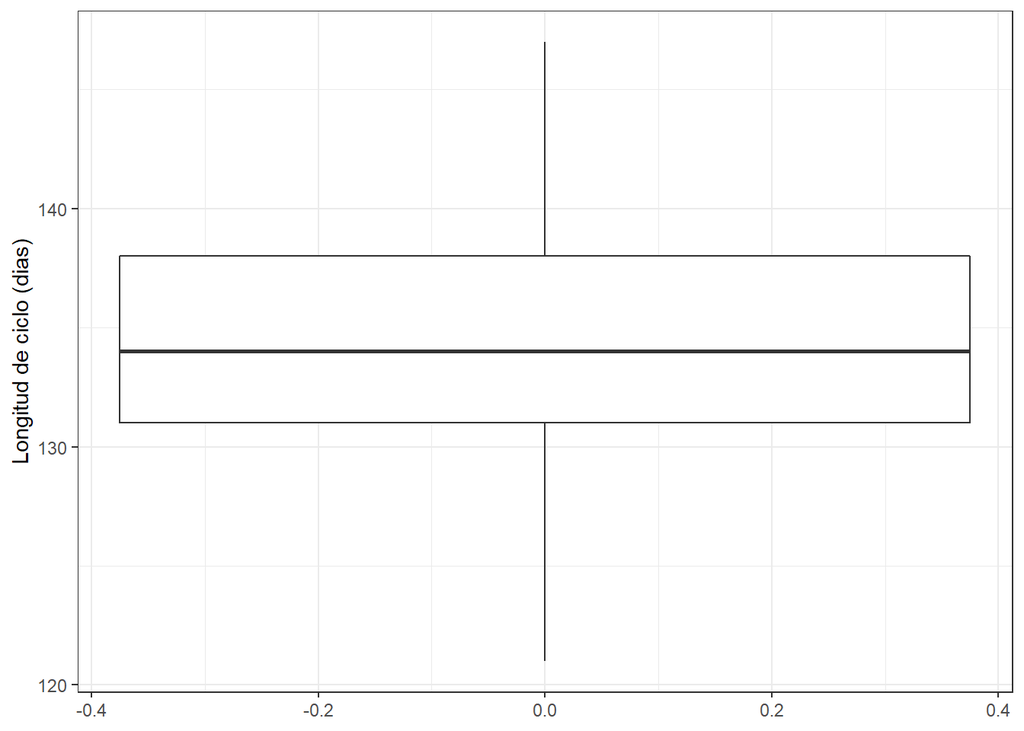

```r
Total_data <- Total_data %>% filter(Longitud_ciclo < 148) %>%
  filter(Longitud_ciclo >120)

ggplot(Total_data,aes(y=Longitud_ciclo))+geom_boxplot()+
  ylab("Longitud de ciclo (dias)")+
  theme_bw()
```

Revisando las estadisticas de los datos se identificaron los valores quye deberian ser eliminados de las listas.

## 4.Organizar la base de datos final

La organizacion de los datos se hara en el orden:

- manejo agronomico
- Variables climáticas
- Variables del suelo
- Rendimiento

```r
Total_data <- Total_data %>% select(Departemento,Farmer_Name,Farmer_Mail,Farmer_Adress,
                                    Planting_Date,Harvest_Date,
                                    Sowing_Seeds_Number,Seeds_Per_Site,
                                    Plant_Density_20_days,Chemical_Treat_Disease,
                                    Chemical_Treat_Weeds,Chemical_Treat_Pests,
                                    Numero_de_tecnicos,Sowing_Method,
                                    Seeds_Treatment,Cultivar,Former_Crop,
                                    Field_Drainage,Harvest_Method,Cultivar_Type,
                                    Longitud_ciclo,TM_Avg_VEG,TA_Avg_VEG,
                                    DR_Avg_VEG,SR_Accu_VEG,
                                    P_10_Freq_VEG,TA_Avg_CF,SR_Accu_CF,
                                    P_Accu_CF,RH_Avg_CF,SR_Accu_MAT,P_10_Freq_MAT,
                                    RH_Avg_MAT,Total_N,Total_P,Total_K,
                                    Number_Chemical_Ferti,pH,Efective_Depth,
                                    Soil_Structure,Runoff,Soil_Texture,
                                    Organic_Matter_Content,Yield)
```

## 5.Summary final

Los datos finales de la tabla ordenada son:

```r
summary(Total_data)
```

```
##  Departemento                 Farmer_Name             Farmer_Mail
##  Length:623         XXXX XXXXX XXXXX:623   XXXXXXXX@XXXXXXXX:623
##  Class :character
##  Mode  :character
##
##
##
##          Farmer_Adress Planting_Date         Harvest_Date
##  XX XXXX  XXXXXX:623   Min.   :2013-04-30   Min.   :2013-09-05
##                        1st Qu.:2015-05-20   1st Qu.:2015-09-28
##                        Median :2015-09-26   Median :2016-02-10
##                        Mean   :2015-09-23   Mean   :2016-02-04
##                        3rd Qu.:2016-05-06   3rd Qu.:2016-09-18
##                        Max.   :2016-06-21   Max.   :2016-10-25
##  Sowing_Seeds_Number Seeds_Per_Site  Plant_Density_20_days
##  Min.   :42424       Min.   :1.000   Min.   : 42000
##  1st Qu.:51515       1st Qu.:1.000   1st Qu.: 60000
##  Median :57576       Median :1.000   Median : 62000
##  Mean   :56956       Mean   :1.438   Mean   : 65771
##  3rd Qu.:60606       3rd Qu.:1.000   3rd Qu.: 70000
##  Max.   :69697       Max.   :5.000   Max.   :700000
##  Chemical_Treat_Disease Chemical_Treat_Weeds Chemical_Treat_Pests
##  Min.   :0.0000         Min.   :0.000        Min.   :0.000
##  1st Qu.:0.0000         1st Qu.:1.000        1st Qu.:1.000
##  Median :0.0000         Median :1.000        Median :2.000
##  Mean   :0.1669         Mean   :1.556        Mean   :1.836
##  3rd Qu.:0.0000         3rd Qu.:2.000        3rd Qu.:2.000
##  Max.   :2.0000         Max.   :5.000        Max.   :9.000
##  Numero_de_tecnicos Sowing_Method      Seeds_Treatment   Cultivar
##  Min.   :1.000      Length:623         NO:362          Length:623
##  1st Qu.:1.000      Class :character   SI:261          Class :character
##  Median :1.000      Mode  :character                   Mode  :character
##  Mean   :1.002
##  3rd Qu.:1.000
##  Max.   :2.000
##  Former_Crop        Field_Drainage Harvest_Method     Cultivar_Type
##  Length:623         NO:278         Length:623         Length:623
##  Class :character   SI:345         Class :character   Class :character
##  Mode  :character                  Mode  :character   Mode  :character
##
```

[output cut: 29 more lines]

```
##  Max.   :87.83   Max.   :0.27600   Max.   :0.047500   Max.   :0.18000
##  Number_Chemical_Ferti       pH        Efective_Depth           Soil_Structure
##  Min.   :1.000         Min.   :4.500   Min.   : 0.00   ATERRONADA      :261
##  1st Qu.:2.000         1st Qu.:5.500   1st Qu.:25.00   GRANULAR        :306
##  Median :2.000         Median :6.000   Median :38.00   MASIVA          : 55
##  Mean   :2.127         Mean   :5.737   Mean   :40.84   SUELTA O POLVOSA:  1
##  3rd Qu.:2.000         3rd Qu.:6.000   3rd Qu.:60.00
##  Max.   :4.000         Max.   :7.000   Max.   :72.00
##       Runoff    Soil_Texture       Organic_Matter_Content     Yield
##  LENTO   :207   Length:623         BAJA :260              Min.   :2.012
##  MODERADO:  1   Class :character   MEDIA:363              1st Qu.:4.100
##  NINGUNO :415   Mode  :character                          Median :5.200
##                                                           Mean   :5.102
##                                                           3rd Qu.:6.100
##                                                           Max.   :7.990
```